# Risk Factor Analysis

## Outcome Variable

**Outcome Variable:** ever_stunted

## Predictor Variables

**Intervention Variable:** tr

**Adjustment Set:**

unadjusted

## Stratifying Variables

The analysis was stratified on these variable(s):

- impfloor
- agecat
- studyid
- country

## Data Summary

| impfloor | agecat | studyid | country | tr | ever_stunted | n_cell | n |
| --- | --- | --- | --- | --- | --- | --- | --- |
| 1 | 0-6 months | ki1000110-WASH-Bangladesh | BANGLADESH | Control | 0 | 4 | 27 |
| 1 | 0-6 months | ki1000110-WASH-Bangladesh | BANGLADESH | Control | 1 | 0 | 27 |
| 1 | 0-6 months | ki1000110-WASH-Bangladesh | BANGLADESH | LNS | 0 | 6 | 27 |
| 1 | 0-6 months | ki1000110-WASH-Bangladesh | BANGLADESH | LNS | 1 | 0 | 27 |
| 1 | 0-6 months | ki1000110-WASH-Bangladesh | BANGLADESH | Other | 0 | 16 | 27 |
| 1 | 0-6 months | ki1000110-WASH-Bangladesh | BANGLADESH | Other | 1 | 1 | 27 |
| 0 | 0-6 months | ki1000111-WASH-Kenya | KENYA | Control | 0 | 24 | 90 |
| 0 | 0-6 months | ki1000111-WASH-Kenya | KENYA | Control | 1 | 2 | 90 |
| 0 | 0-6 months | ki1000111-WASH-Kenya | KENYA | LNS | 0 | 23 | 90 |
| 0 | 0-6 months | ki1000111-WASH-Kenya | KENYA | LNS | 1 | 0 | 90 |
| 0 | 0-6 months | ki1000111-WASH-Kenya | KENYA | Other | 0 | 36 | 90 |
| 0 | 0-6 months | ki1000111-WASH-Kenya | KENYA | Other | 1 | 5 | 90 |
| 1 | 0-6 months | ki1000111-WASH-Kenya | KENYA | Control | 0 | 1 | 2 |
| 1 | 0-6 months | ki1000111-WASH-Kenya | KENYA | Other | 0 | 1 | 2 |
| 0 | 0-6 months | ki1000125-AgaKhanUniv | PAKISTAN | Control | 0 | 16 | 59 |
| 0 | 0-6 months | ki1000125-AgaKhanUniv | PAKISTAN | Control | 1 | 6 | 59 |
| 0 | 0-6 months | ki1000125-AgaKhanUniv | PAKISTAN | Maternal | 0 | 30 | 59 |
| 0 | 0-6 months | ki1000125-AgaKhanUniv | PAKISTAN | Maternal | 1 | 7 | 59 |
| 1 | 0-6 months | ki1000125-AgaKhanUniv | PAKISTAN | Control | 0 | 19 | 38 |
| 1 | 0-6 months | ki1000125-AgaKhanUniv | PAKISTAN | Control | 1 | 6 | 38 |
| 1 | 0-6 months | ki1000125-AgaKhanUniv | PAKISTAN | Maternal | 0 | 11 | 38 |
| 1 | 0-6 months | ki1000125-AgaKhanUniv | PAKISTAN | Maternal | 1 | 2 | 38 |
| 0 | 0-6 months | ki1000304-VITAMIN-A | INDIA | Control | 0 | 4 | 11 |
| 0 | 0-6 months | ki1000304-VITAMIN-A | INDIA | Control | 1 | 1 | 11 |
| 0 | 0-6 months | ki1000304-VITAMIN-A | INDIA | VitA | 0 | 5 | 11 |
| 0 | 0-6 months | ki1000304-VITAMIN-A | INDIA | VitA | 1 | 1 | 11 |
| 1 | 0-6 months | ki1017093b-PROVIDE | BANGLADESH | Control | 0 | 133 | 586 |
| 1 | 0-6 months | ki1017093b-PROVIDE | BANGLADESH | Control | 1 | 19 | 586 |
| 1 | 0-6 months | ki1017093b-PROVIDE | BANGLADESH | Other | 0 | 379 | 586 |
| 1 | 0-6 months | ki1017093b-PROVIDE | BANGLADESH | Other | 1 | 55 | 586 |

[output cut: 140 more lines]

The following strata were considered:

- impfloor: 0, agecat: 0-24 months, studyid: ki1000111-WASH-Kenya, country: KENYA
- impfloor: 0, agecat: 0-24 months, studyid: ki1000125-AgaKhanUniv, country: PAKISTAN
- impfloor: 0, agecat: 0-24 months, studyid: ki1000304-VITAMIN-A, country: INDIA
- impfloor: 0, agecat: 0-24 months, studyid: ki1017093b-PROVIDE, country: BANGLADESH
- impfloor: 0, agecat: 0-24 months, studyid: kiGH5241-JiVitA-3, country: BANGLADESH
- impfloor: 0, agecat: 0-24 months, studyid: kiGH5241-JiVitA-4, country: BANGLADESH
- impfloor: 0, agecat: 0-6 months, studyid: ki1000111-WASH-Kenya, country: KENYA
- impfloor: 0, agecat: 0-6 months, studyid: ki1000125-AgaKhanUniv, country: PAKISTAN
- impfloor: 0, agecat: 0-6 months, studyid: ki1000304-VITAMIN-A, country: INDIA
- impfloor: 0, agecat: 0-6 months, studyid: ki1017093b-PROVIDE, country: BANGLADESH
- impfloor: 0, agecat: 0-6 months, studyid: kiGH5241-JiVitA-3, country: BANGLADESH
- impfloor: 0, agecat: 0-6 months, studyid: kiGH5241-JiVitA-4, country: BANGLADESH
- impfloor: 0, agecat: 6-24 months, studyid: ki1000111-WASH-Kenya, country: KENYA
- impfloor: 0, agecat: 6-24 months, studyid: ki1000125-AgaKhanUniv, country: PAKISTAN
- impfloor: 0, agecat: 6-24 months, studyid: ki1000304-VITAMIN-A, country: INDIA
- impfloor: 0, agecat: 6-24 months, studyid: ki1017093b-PROVIDE, country: BANGLADESH
- impfloor: 0, agecat: 6-24 months, studyid: kiGH5241-JiVitA-3, country: BANGLADESH
- impfloor: 0, agecat: 6-24 months, studyid: kiGH5241-JiVitA-4, country: BANGLADESH
- impfloor: 1, agecat: 0-24 months, studyid: ki1000110-WASH-Bangladesh, country: BANGLADESH
- impfloor: 1, agecat: 0-24 months, studyid: ki1000111-WASH-Kenya, country: KENYA
- impfloor: 1, agecat: 0-24 months, studyid: ki1000125-AgaKhanUniv, country: PAKISTAN
- impfloor: 1, agecat: 0-24 months, studyid: ki1017093b-PROVIDE, country: BANGLADESH
- impfloor: 1, agecat: 0-24 months, studyid: kiGH5241-JiVitA-3, country: BANGLADESH
- impfloor: 1, agecat: 0-24 months, studyid: kiGH5241-JiVitA-4, country: BANGLADESH
- impfloor: 1, agecat: 0-6 months, studyid: ki1000110-WASH-Bangladesh, country: BANGLADESH
- impfloor: 1, agecat: 0-6 months, studyid: ki1000111-WASH-Kenya, country: KENYA
- impfloor: 1, agecat: 0-6 months, studyid: ki1000125-AgaKhanUniv, country: PAKISTAN
- impfloor: 1, agecat: 0-6 months, studyid: ki1017093b-PROVIDE, country: BANGLADESH
- impfloor: 1, agecat: 0-6 months, studyid: kiGH5241-JiVitA-3, country: BANGLADESH
- impfloor: 1, agecat: 0-6 months, studyid: kiGH5241-JiVitA-4, country: BANGLADESH
- impfloor: 1, agecat: 6-24 months, studyid: ki1000110-WASH-Bangladesh, country: BANGLADESH
- impfloor: 1, agecat: 6-24 months, studyid: ki1000111-WASH-Kenya, country: KENYA
- impfloor: 1, agecat: 6-24 months, studyid: ki1000125-AgaKhanUniv, country: PAKISTAN
- impfloor: 1, agecat: 6-24 months, studyid: ki1017093b-PROVIDE, country: BANGLADESH
- impfloor: 1, agecat: 6-24 months, studyid: kiGH5241-JiVitA-3, country: BANGLADESH
- impfloor: 1, agecat: 6-24 months, studyid: kiGH5241-JiVitA-4, country: BANGLADESH

### Dropped Strata

Some strata were dropped due to rare outcomes:

- impfloor: 1, agecat: 0-6 months, studyid: ki1000110-WASH-Bangladesh, country: BANGLADESH
- impfloor: 0, agecat: 0-6 months, studyid: ki1000111-WASH-Kenya, country: KENYA
- impfloor: 1, agecat: 0-6 months, studyid: ki1000111-WASH-Kenya, country: KENYA
- impfloor: 1, agecat: 0-6 months, studyid: ki1000125-AgaKhanUniv, country: PAKISTAN
- impfloor: 0, agecat: 0-6 months, studyid: ki1000304-VITAMIN-A, country: INDIA
- impfloor: 1, agecat: 6-24 months, studyid: ki1000111-WASH-Kenya, country: KENYA
- impfloor: 1, agecat: 6-24 months, studyid: ki1000125-AgaKhanUniv, country: PAKISTAN
- impfloor: 0, agecat: 6-24 months, studyid: ki1000125-AgaKhanUniv, country: PAKISTAN
- impfloor: 0, agecat: 6-24 months, studyid: ki1017093b-PROVIDE, country: BANGLADESH

## Methods Detail

We’re interested in the causal parameters $E[Y_a]$ for all values of $a \in \mathcal{A}$. These parameters represent the mean outcome if, possibly contrary to fact, we intervened to set all units to have $A=a$. Under the randomization and positivity assumptions, these are identified by the statistical parameters $\psi_a=E_W[E_{Y|A,W}(Y|A=a,W)]$. In addition, we’re interested in the mean of $Y$, $E[Y]$ under no intervention (the observed mean). We will estimate these parameters by using SuperLearner to fit the relevant likelihood factors – $E_{Y|A,W}(Y|A=a,W)$ and $p(A=a|W)$, and then updating our likelihood fit using a joint TMLE.

For unadjusted analyses ($W=\{\}$), initial likelihoods were estimated using Lrnr_glm to estimate the simple $E(Y|A)$ and Lrnr_mean to estimate $p(A)$. For adjusted analyses, a small library containing Lrnr_glmnet, Lrnr_xgboost, and Lrnr_mean was used.

Having estimated these parameters, we will then use the delta method to estimate relative risks and attributable risks relative to a prespecified baseline level of $A$.

# Results Detail

## Results Plots

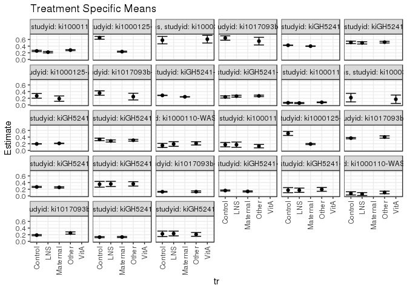

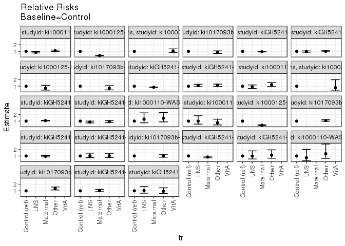

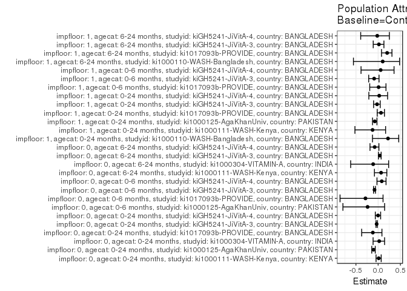

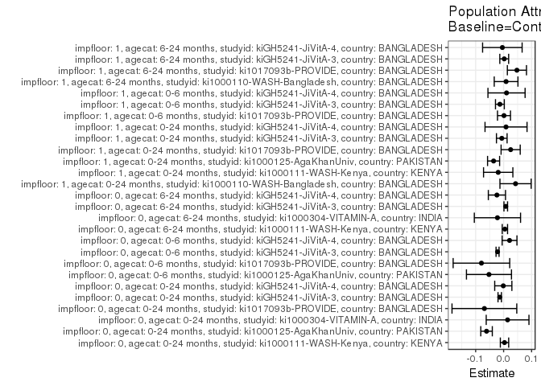

## Results Table

### Parameter: TSM

| impfloor | agecat | studyid | country | intervention_level | baseline_level | estimate | ci_lower | ci_upper |
| --- | --- | --- | --- | --- | --- | --- | --- | --- |
| 0 | 0-24 months | ki1000111-WASH-Kenya | KENYA | Control | NA | 0.2552995 | 0.2369524 | 0.2736467 |
| 0 | 0-24 months | ki1000111-WASH-Kenya | KENYA | LNS | NA | 0.2189306 | 0.1971429 | 0.2407184 |
| 0 | 0-24 months | ki1000111-WASH-Kenya | KENYA | Other | NA | 0.2807081 | 0.2639672 | 0.2974490 |
| 0 | 0-24 months | ki1000125-AgaKhanUniv | PAKISTAN | Control | NA | 0.6495957 | 0.6081431 | 0.6910483 |
| 0 | 0-24 months | ki1000125-AgaKhanUniv | PAKISTAN | Maternal | NA | 0.2343750 | 0.2190884 | 0.2496616 |
| 0 | 0-24 months | ki1000304-VITAMIN-A | INDIA | Control | NA | 0.5789474 | 0.4675611 | 0.6903337 |
| 0 | 0-24 months | ki1000304-VITAMIN-A | INDIA | VitA | NA | 0.6086957 | 0.4931420 | 0.7242493 |
| 0 | 0-24 months | ki1017093b-PROVIDE | BANGLADESH | Control | NA | 0.6428571 | 0.5771738 | 0.7085405 |
| 0 | 0-24 months | ki1017093b-PROVIDE | BANGLADESH | Other | NA | 0.5500000 | 0.4347261 | 0.6652739 |
| 0 | 0-24 months | kiGH5241-JiVitA-3 | BANGLADESH | Control | NA | 0.4260094 | 0.4198776 | 0.4321412 |
| 0 | 0-24 months | kiGH5241-JiVitA-3 | BANGLADESH | Maternal | NA | 0.3983027 | 0.3924013 | 0.4042041 |
| 0 | 0-24 months | kiGH5241-JiVitA-4 | BANGLADESH | Control | NA | 0.5125984 | 0.4758870 | 0.5493098 |
| 0 | 0-24 months | kiGH5241-JiVitA-4 | BANGLADESH | LNS | NA | 0.4976994 | 0.4641135 | 0.5312852 |
| 0 | 0-24 months | kiGH5241-JiVitA-4 | BANGLADESH | Other | NA | 0.5188379 | 0.4942104 | 0.5434655 |
| 0 | 0-6 months | ki1000125-AgaKhanUniv | PAKISTAN | Control | NA | 0.2727273 | 0.2027379 | 0.3427167 |
| 0 | 0-6 months | ki1000125-AgaKhanUniv | PAKISTAN | Maternal | NA | 0.1891892 | 0.1093682 | 0.2690101 |
| 0 | 0-6 months | ki1017093b-PROVIDE | BANGLADESH | Control | NA | 0.3571429 | 0.2914595 | 0.4228262 |
| 0 | 0-6 months | ki1017093b-PROVIDE | BANGLADESH | Other | NA | 0.2500000 | 0.1496670 | 0.3503330 |
| 0 | 0-6 months | kiGH5241-JiVitA-3 | BANGLADESH | Control | NA | 0.2870433 | 0.2815543 | 0.2925324 |
| 0 | 0-6 months | kiGH5241-JiVitA-3 | BANGLADESH | Maternal | NA | 0.2439352 | 0.2389127 | 0.2489576 |
| 0 | 0-6 months | kiGH5241-JiVitA-4 | BANGLADESH | Control | NA | 0.2399618 | 0.2086936 | 0.2712299 |
| 0 | 0-6 months | kiGH5241-JiVitA-4 | BANGLADESH | LNS | NA | 0.2633028 | 0.2361122 | 0.2904933 |
| 0 | 0-6 months | kiGH5241-JiVitA-4 | BANGLADESH | Other | NA | 0.2716578 | 0.2490490 | 0.2942665 |
| 0 | 6-24 months | ki1000111-WASH-Kenya | KENYA | Control | NA | 0.0641026 | 0.0525125 | 0.0756926 |
| 0 | 6-24 months | ki1000111-WASH-Kenya | KENYA | LNS | NA | 0.0570676 | 0.0435946 | 0.0705406 |
| 0 | 6-24 months | ki1000111-WASH-Kenya | KENYA | Other | NA | 0.0783948 | 0.0670134 | 0.0897762 |
| 0 | 6-24 months | ki1000304-VITAMIN-A | INDIA | Control | NA | 0.2195122 | 0.0919727 | 0.3470517 |
| 0 | 6-24 months | ki1000304-VITAMIN-A | INDIA | VitA | NA | 0.1714286 | 0.0457397 | 0.2971174 |
| 0 | 6-24 months | kiGH5241-JiVitA-3 | BANGLADESH | Control | NA | 0.1965110 | 0.1908148 | 0.2022073 |
| 0 | 6-24 months | kiGH5241-JiVitA-3 | BANGLADESH | Maternal | NA | 0.2114314 | 0.2049876 | 0.2178751 |
| 0 | 6-24 months | kiGH5241-JiVitA-4 | BANGLADESH | Control | NA | 0.3303748 | 0.2934285 | 0.3673210 |
| 0 | 6-24 months | kiGH5241-JiVitA-4 | BANGLADESH | LNS | NA | 0.2832031 | 0.2518613 | 0.3145450 |
| 0 | 6-24 months | kiGH5241-JiVitA-4 | BANGLADESH | Other | NA | 0.3060142 | 0.2797966 | 0.3322317 |
| 1 | 0-24 months | ki1000110-WASH-Bangladesh | BANGLADESH | Control | NA | 0.1496063 | 0.0875118 | 0.2117008 |
| 1 | 0-24 months | ki1000110-WASH-Bangladesh | BANGLADESH | LNS | NA | 0.1935484 | 0.1239429 | 0.2631538 |
| 1 | 0-24 months | ki1000110-WASH-Bangladesh | BANGLADESH | Other | NA | 0.2121212 | 0.1627595 | 0.2614829 |
| 1 | 0-24 months | ki1000111-WASH-Kenya | KENYA | Control | NA | 0.1732283 | 0.1073223 | 0.2391344 |
| 1 | 0-24 months | ki1000111-WASH-Kenya | KENYA | LNS | NA | 0.1724138 | 0.0929338 | 0.2518938 |
| 1 | 0-24 months | ki1000111-WASH-Kenya | KENYA | Other | NA | 0.1288344 | 0.0773355 | 0.1803332 |
| 1 | 0-24 months | ki1000125-AgaKhanUniv | PAKISTAN | Control | NA | 0.5098039 | 0.4488266 | 0.5707812 |
| 1 | 0-24 months | ki1000125-AgaKhanUniv | PAKISTAN | Maternal | NA | 0.1923077 | 0.1751454 | 0.2094699 |
| 1 | 0-24 months | ki1017093b-PROVIDE | BANGLADESH | Control | NA | 0.3684211 | 0.3485469 | 0.3882952 |
| 1 | 0-24 months | ki1017093b-PROVIDE | BANGLADESH | Other | NA | 0.4022989 | 0.3681213 | 0.4364764 |
| 1 | 0-24 months | kiGH5241-JiVitA-3 | BANGLADESH | Control | NA | 0.2690583 | 0.2520928 | 0.2860238 |
| 1 | 0-24 months | kiGH5241-JiVitA-3 | BANGLADESH | Maternal | NA | 0.2562500 | 0.2372244 | 0.2752756 |
| 1 | 0-24 months | kiGH5241-JiVitA-4 | BANGLADESH | Control | NA | 0.3500000 | 0.2638289 | 0.4361711 |
| 1 | 0-24 months | kiGH5241-JiVitA-4 | BANGLADESH | LNS | NA | 0.3602151 | 0.2833533 | 0.4370768 |
| 1 | 0-24 months | kiGH5241-JiVitA-4 | BANGLADESH | Other | NA | 0.3621262 | 0.2960444 | 0.4282081 |
| 1 | 0-6 months | ki1017093b-PROVIDE | BANGLADESH | Control | NA | 0.1250000 | 0.1113510 | 0.1386490 |
| 1 | 0-6 months | ki1017093b-PROVIDE | BANGLADESH | Other | NA | 0.1267281 | 0.1035287 | 0.1499275 |
| 1 | 0-6 months | kiGH5241-JiVitA-3 | BANGLADESH | Control | NA | 0.1614173 | 0.1464246 | 0.1764100 |
| 1 | 0-6 months | kiGH5241-JiVitA-3 | BANGLADESH | Maternal | NA | 0.1353383 | 0.1195944 | 0.1510823 |
| 1 | 0-6 months | kiGH5241-JiVitA-4 | BANGLADESH | Control | NA | 0.1729323 | 0.0967272 | 0.2491374 |
| 1 | 0-6 months | kiGH5241-JiVitA-4 | BANGLADESH | LNS | NA | 0.1708861 | 0.1062011 | 0.2355711 |
| 1 | 0-6 months | kiGH5241-JiVitA-4 | BANGLADESH | Other | NA | 0.1961538 | 0.1393271 | 0.2529806 |
| 1 | 6-24 months | ki1000110-WASH-Bangladesh | BANGLADESH | Control | NA | 0.0769231 | 0.0285860 | 0.1252601 |
| 1 | 6-24 months | ki1000110-WASH-Bangladesh | BANGLADESH | LNS | NA | 0.0566038 | 0.0125642 | 0.1006433 |
| 1 | 6-24 months | ki1000110-WASH-Bangladesh | BANGLADESH | Other | NA | 0.1034483 | 0.0642171 | 0.1426794 |
| 1 | 6-24 months | ki1017093b-PROVIDE | BANGLADESH | Control | NA | 0.1880342 | 0.1702769 | 0.2057915 |
| 1 | 6-24 months | ki1017093b-PROVIDE | BANGLADESH | Other | NA | 0.2514286 | 0.2173285 | 0.2855286 |
| 1 | 6-24 months | kiGH5241-JiVitA-3 | BANGLADESH | Control | NA | 0.1271860 | 0.1121597 | 0.1422123 |
| 1 | 6-24 months | kiGH5241-JiVitA-3 | BANGLADESH | Maternal | NA | 0.1313131 | 0.1155270 | 0.1470993 |
| 1 | 6-24 months | kiGH5241-JiVitA-4 | BANGLADESH | Control | NA | 0.2269504 | 0.1444065 | 0.3094942 |
| 1 | 6-24 months | kiGH5241-JiVitA-4 | BANGLADESH | LNS | NA | 0.2366864 | 0.1647857 | 0.3085871 |
| 1 | 6-24 months | kiGH5241-JiVitA-4 | BANGLADESH | Other | NA | 0.2107280 | 0.1540476 | 0.2674084 |

### Parameter: E(Y)

| impfloor | agecat | studyid | country | intervention_level | baseline_level | estimate | ci_lower | ci_upper |
| --- | --- | --- | --- | --- | --- | --- | --- | --- |
| 0 | 0-24 months | ki1000111-WASH-Kenya | KENYA | NA | NA | 0.2584625 | 0.2476700 | 0.2692550 |
| 0 | 0-24 months | ki1000125-AgaKhanUniv | PAKISTAN | NA | NA | 0.5885057 | 0.5422079 | 0.6348036 |
| 0 | 0-24 months | ki1000304-VITAMIN-A | INDIA | NA | NA | 0.5931034 | 0.5128666 | 0.6733403 |
| 0 | 0-24 months | ki1017093b-PROVIDE | BANGLADESH | NA | NA | 0.5740741 | 0.4409486 | 0.7071995 |
| 0 | 0-24 months | kiGH5241-JiVitA-3 | BANGLADESH | NA | NA | 0.4120388 | 0.4034338 | 0.4206438 |
| 0 | 0-24 months | kiGH5241-JiVitA-4 | BANGLADESH | NA | NA | 0.5114088 | 0.4938480 | 0.5289697 |
| 0 | 0-6 months | ki1000125-AgaKhanUniv | PAKISTAN | NA | NA | 0.2203390 | 0.1136713 | 0.3270066 |
| 0 | 0-6 months | ki1017093b-PROVIDE | BANGLADESH | NA | NA | 0.2777778 | 0.1571925 | 0.3983631 |
| 0 | 0-6 months | kiGH5241-JiVitA-3 | BANGLADESH | NA | NA | 0.2653303 | 0.2576977 | 0.2729628 |
| 0 | 0-6 months | kiGH5241-JiVitA-4 | BANGLADESH | NA | NA | 0.2611083 | 0.2458097 | 0.2764070 |
| 0 | 6-24 months | ki1000111-WASH-Kenya | KENYA | NA | NA | 0.0686275 | 0.0616177 | 0.0756372 |
| 0 | 6-24 months | ki1000304-VITAMIN-A | INDIA | NA | NA | 0.1973684 | 0.1072913 | 0.2874455 |
| 0 | 6-24 months | kiGH5241-JiVitA-3 | BANGLADESH | NA | NA | 0.2041329 | 0.1955387 | 0.2127271 |
| 0 | 6-24 months | kiGH5241-JiVitA-4 | BANGLADESH | NA | NA | 0.3063739 | 0.2885292 | 0.3242185 |
| 1 | 0-24 months | ki1000110-WASH-Bangladesh | BANGLADESH | NA | NA | 0.1922330 | 0.1581668 | 0.2262992 |
| 1 | 0-24 months | ki1000111-WASH-Kenya | KENYA | NA | NA | 0.1538462 | 0.1173773 | 0.1903150 |
| 1 | 0-24 months | ki1000125-AgaKhanUniv | PAKISTAN | NA | NA | 0.4739130 | 0.4092422 | 0.5385839 |
| 1 | 0-24 months | ki1017093b-PROVIDE | BANGLADESH | NA | NA | 0.3935264 | 0.3539722 | 0.4330806 |
| 1 | 0-24 months | kiGH5241-JiVitA-3 | BANGLADESH | NA | NA | 0.2624190 | 0.2369321 | 0.2879059 |
| 1 | 0-24 months | kiGH5241-JiVitA-4 | BANGLADESH | NA | NA | 0.3585781 | 0.3151245 | 0.4020316 |
| 1 | 0-6 months | ki1017093b-PROVIDE | BANGLADESH | NA | NA | 0.1262799 | 0.0993631 | 0.1531967 |
| 1 | 0-6 months | kiGH5241-JiVitA-3 | BANGLADESH | NA | NA | 0.1480769 | 0.1263449 | 0.1698089 |
| 1 | 0-6 months | kiGH5241-JiVitA-4 | BANGLADESH | NA | NA | 0.1833031 | 0.1458593 | 0.2207468 |
| 1 | 6-24 months | ki1000110-WASH-Bangladesh | BANGLADESH | NA | NA | 0.0857143 | 0.0599637 | 0.1114649 |
| 1 | 6-24 months | ki1017093b-PROVIDE | BANGLADESH | NA | NA | 0.2355460 | 0.1970187 | 0.2740733 |
| 1 | 6-24 months | kiGH5241-JiVitA-3 | BANGLADESH | NA | NA | 0.1293495 | 0.1075511 | 0.1511479 |
| 1 | 6-24 months | kiGH5241-JiVitA-4 | BANGLADESH | NA | NA | 0.2224168 | 0.1831216 | 0.2617120 |

### Parameter: RR

| impfloor | agecat | studyid | country | intervention_level | baseline_level | estimate | ci_lower | ci_upper |
| --- | --- | --- | --- | --- | --- | --- | --- | --- |
| 0 | 0-24 months | ki1000111-WASH-Kenya | KENYA | Control | Control | 1.0000000 | 1.0000000 | 1.0000000 |
| 0 | 0-24 months | ki1000111-WASH-Kenya | KENYA | LNS | Control | 0.8575442 | 0.7584815 | 0.9695452 |
| 0 | 0-24 months | ki1000111-WASH-Kenya | KENYA | Other | Control | 1.0995245 | 1.0014909 | 1.2071543 |
| 0 | 0-24 months | ki1000125-AgaKhanUniv | PAKISTAN | Control | Control | 1.0000000 | 1.0000000 | 1.0000000 |
| 0 | 0-24 months | ki1000125-AgaKhanUniv | PAKISTAN | Maternal | Control | 0.3608013 | 0.3293364 | 0.3952724 |
| 0 | 0-24 months | ki1000304-VITAMIN-A | INDIA | Control | Control | 1.0000000 | 1.0000000 | 1.0000000 |
| 0 | 0-24 months | ki1000304-VITAMIN-A | INDIA | VitA | Control | 1.0513834 | 0.8023755 | 1.3776680 |
| 0 | 0-24 months | ki1017093b-PROVIDE | BANGLADESH | Control | Control | 1.0000000 | 1.0000000 | 1.0000000 |
| 0 | 0-24 months | ki1017093b-PROVIDE | BANGLADESH | Other | Control | 0.8555556 | 0.6776179 | 1.0802183 |
| 0 | 0-24 months | kiGH5241-JiVitA-3 | BANGLADESH | Control | Control | 1.0000000 | 1.0000000 | 1.0000000 |
| 0 | 0-24 months | kiGH5241-JiVitA-3 | BANGLADESH | Maternal | Control | 0.9349622 | 0.9158229 | 0.9545015 |
| 0 | 0-24 months | kiGH5241-JiVitA-4 | BANGLADESH | Control | Control | 1.0000000 | 1.0000000 | 1.0000000 |
| 0 | 0-24 months | kiGH5241-JiVitA-4 | BANGLADESH | LNS | Control | 0.9709343 | 0.8798797 | 1.0714117 |
| 0 | 0-24 months | kiGH5241-JiVitA-4 | BANGLADESH | Other | Control | 1.0121723 | 0.9287973 | 1.1030316 |
| 0 | 0-6 months | ki1000125-AgaKhanUniv | PAKISTAN | Control | Control | 1.0000000 | 1.0000000 | 1.0000000 |
| 0 | 0-6 months | ki1000125-AgaKhanUniv | PAKISTAN | Maternal | Control | 0.6936937 | 0.4233512 | 1.1366708 |
| 0 | 0-6 months | ki1017093b-PROVIDE | BANGLADESH | Control | Control | 1.0000000 | 1.0000000 | 1.0000000 |
| 0 | 0-6 months | ki1017093b-PROVIDE | BANGLADESH | Other | Control | 0.7000000 | 0.4501654 | 1.0884889 |
| 0 | 0-6 months | kiGH5241-JiVitA-3 | BANGLADESH | Control | Control | 1.0000000 | 1.0000000 | 1.0000000 |
| 0 | 0-6 months | kiGH5241-JiVitA-3 | BANGLADESH | Maternal | Control | 0.8498200 | 0.8262600 | 0.8740517 |
| 0 | 0-6 months | kiGH5241-JiVitA-4 | BANGLADESH | Control | Control | 1.0000000 | 1.0000000 | 1.0000000 |
| 0 | 0-6 months | kiGH5241-JiVitA-4 | BANGLADESH | LNS | Control | 1.0972696 | 0.9292124 | 1.2957217 |
| 0 | 0-6 months | kiGH5241-JiVitA-4 | BANGLADESH | Other | Control | 1.1320877 | 0.9699067 | 1.3213875 |
| 0 | 6-24 months | ki1000111-WASH-Kenya | KENYA | Control | Control | 1.0000000 | 1.0000000 | 1.0000000 |
| 0 | 6-24 months | ki1000111-WASH-Kenya | KENYA | LNS | Control | 0.8902546 | 0.6612545 | 1.1985601 |
| 0 | 6-24 months | ki1000111-WASH-Kenya | KENYA | Other | Control | 1.2229585 | 0.9698577 | 1.5421101 |
| 0 | 6-24 months | ki1000304-VITAMIN-A | INDIA | Control | Control | 1.0000000 | 1.0000000 | 1.0000000 |
| 0 | 6-24 months | ki1000304-VITAMIN-A | INDIA | VitA | Control | 0.7809524 | 0.3064415 | 1.9902223 |
| 0 | 6-24 months | kiGH5241-JiVitA-3 | BANGLADESH | Control | Control | 1.0000000 | 1.0000000 | 1.0000000 |
| 0 | 6-24 months | kiGH5241-JiVitA-3 | BANGLADESH | Maternal | Control | 1.0759263 | 1.0315948 | 1.1221628 |
| 0 | 6-24 months | kiGH5241-JiVitA-4 | BANGLADESH | Control | Control | 1.0000000 | 1.0000000 | 1.0000000 |
| 0 | 6-24 months | kiGH5241-JiVitA-4 | BANGLADESH | LNS | Control | 0.8572178 | 0.7324229 | 1.0032761 |
| 0 | 6-24 months | kiGH5241-JiVitA-4 | BANGLADESH | Other | Control | 0.9262637 | 0.8045484 | 1.0663926 |
| 1 | 0-24 months | ki1000110-WASH-Bangladesh | BANGLADESH | Control | Control | 1.0000000 | 1.0000000 | 1.0000000 |
| 1 | 0-24 months | ki1000110-WASH-Bangladesh | BANGLADESH | LNS | Control | 1.2937182 | 0.7470210 | 2.2405082 |
| 1 | 0-24 months | ki1000110-WASH-Bangladesh | BANGLADESH | Other | Control | 1.4178628 | 0.8810103 | 2.2818518 |
| 1 | 0-24 months | ki1000111-WASH-Kenya | KENYA | Control | Control | 1.0000000 | 1.0000000 | 1.0000000 |
| 1 | 0-24 months | ki1000111-WASH-Kenya | KENYA | LNS | Control | 0.9952978 | 0.5474847 | 1.8093980 |
| 1 | 0-24 months | ki1000111-WASH-Kenya | KENYA | Other | Control | 0.7437256 | 0.4283021 | 1.2914432 |
| 1 | 0-24 months | ki1000125-AgaKhanUniv | PAKISTAN | Control | Control | 1.0000000 | 1.0000000 | 1.0000000 |
| 1 | 0-24 months | ki1000125-AgaKhanUniv | PAKISTAN | Maternal | Control | 0.3772189 | 0.3249241 | 0.4379303 |
| 1 | 0-24 months | ki1017093b-PROVIDE | BANGLADESH | Control | Control | 1.0000000 | 1.0000000 | 1.0000000 |
| 1 | 0-24 months | ki1017093b-PROVIDE | BANGLADESH | Other | Control | 1.0919540 | 0.9874135 | 1.2075626 |
| 1 | 0-24 months | kiGH5241-JiVitA-3 | BANGLADESH | Control | Control | 1.0000000 | 1.0000000 | 1.0000000 |
| 1 | 0-24 months | kiGH5241-JiVitA-3 | BANGLADESH | Maternal | Control | 0.9523958 | 0.8640689 | 1.0497518 |
| 1 | 0-24 months | kiGH5241-JiVitA-4 | BANGLADESH | Control | Control | 1.0000000 | 1.0000000 | 1.0000000 |
| 1 | 0-24 months | kiGH5241-JiVitA-4 | BANGLADESH | LNS | Control | 1.0291859 | 0.7429613 | 1.4256780 |
| 1 | 0-24 months | kiGH5241-JiVitA-4 | BANGLADESH | Other | Control | 1.0346464 | 0.7615898 | 1.4056034 |
| 1 | 0-6 months | ki1017093b-PROVIDE | BANGLADESH | Control | Control | 1.0000000 | 1.0000000 | 1.0000000 |
| 1 | 0-6 months | ki1017093b-PROVIDE | BANGLADESH | Other | Control | 1.0138249 | 0.8192007 | 1.2546875 |
| 1 | 0-6 months | kiGH5241-JiVitA-3 | BANGLADESH | Control | Control | 1.0000000 | 1.0000000 | 1.0000000 |
| 1 | 0-6 months | kiGH5241-JiVitA-3 | BANGLADESH | Maternal | Control | 0.8384376 | 0.7225181 | 0.9729549 |
| 1 | 0-6 months | kiGH5241-JiVitA-4 | BANGLADESH | Control | Control | 1.0000000 | 1.0000000 | 1.0000000 |
| 1 | 0-6 months | kiGH5241-JiVitA-4 | BANGLADESH | LNS | Control | 0.9881673 | 0.5527629 | 1.7665343 |
| 1 | 0-6 months | kiGH5241-JiVitA-4 | BANGLADESH | Other | Control | 1.1342809 | 0.6694223 | 1.9219455 |
| 1 | 6-24 months | ki1000110-WASH-Bangladesh | BANGLADESH | Control | Control | 1.0000000 | 1.0000000 | 1.0000000 |
| 1 | 6-24 months | ki1000110-WASH-Bangladesh | BANGLADESH | LNS | Control | 0.7358491 | 0.2706771 | 2.0004421 |
| 1 | 6-24 months | ki1000110-WASH-Bangladesh | BANGLADESH | Other | Control | 1.3448276 | 0.6455297 | 2.8016702 |
| 1 | 6-24 months | ki1017093b-PROVIDE | BANGLADESH | Control | Control | 1.0000000 | 1.0000000 | 1.0000000 |
| 1 | 6-24 months | ki1017093b-PROVIDE | BANGLADESH | Other | Control | 1.3371429 | 1.1334549 | 1.5774346 |
| 1 | 6-24 months | kiGH5241-JiVitA-3 | BANGLADESH | Control | Control | 1.0000000 | 1.0000000 | 1.0000000 |
| 1 | 6-24 months | kiGH5241-JiVitA-3 | BANGLADESH | Maternal | Control | 1.0324495 | 0.8723082 | 1.2219901 |
| 1 | 6-24 months | kiGH5241-JiVitA-4 | BANGLADESH | Control | Control | 1.0000000 | 1.0000000 | 1.0000000 |
| 1 | 6-24 months | kiGH5241-JiVitA-4 | BANGLADESH | LNS | Control | 1.0428994 | 0.6491679 | 1.6754358 |
| 1 | 6-24 months | kiGH5241-JiVitA-4 | BANGLADESH | Other | Control | 0.9285201 | 0.5906891 | 1.4595657 |

### Parameter: PAR

| impfloor | agecat | studyid | country | intervention_level | baseline_level | estimate | ci_lower | ci_upper |
| --- | --- | --- | --- | --- | --- | --- | --- | --- |
| 0 | 0-24 months | ki1000111-WASH-Kenya | KENYA | Control | NA | 0.0031630 | -0.0117370 | 0.0180630 |
| 0 | 0-24 months | ki1000125-AgaKhanUniv | PAKISTAN | Control | NA | -0.0610899 | -0.0817096 | -0.0404703 |
| 0 | 0-24 months | ki1000304-VITAMIN-A | INDIA | Control | NA | 0.0141561 | -0.0622573 | 0.0905695 |
| 0 | 0-24 months | ki1017093b-PROVIDE | BANGLADESH | Control | NA | -0.0687831 | -0.1845764 | 0.0470102 |
| 0 | 0-24 months | kiGH5241-JiVitA-3 | BANGLADESH | Control | NA | -0.0139706 | -0.0200601 | -0.0078811 |
| 0 | 0-24 months | kiGH5241-JiVitA-4 | BANGLADESH | Control | NA | -0.0011896 | -0.0318746 | 0.0294954 |
| 0 | 0-6 months | ki1000125-AgaKhanUniv | PAKISTAN | Control | NA | -0.0523883 | -0.1328834 | 0.0281068 |
| 0 | 0-6 months | ki1017093b-PROVIDE | BANGLADESH | Control | NA | -0.0793651 | -0.1804913 | 0.0217611 |
| 0 | 0-6 months | kiGH5241-JiVitA-3 | BANGLADESH | Control | NA | -0.0217131 | -0.0270803 | -0.0163459 |
| 0 | 0-6 months | kiGH5241-JiVitA-4 | BANGLADESH | Control | NA | 0.0211466 | -0.0053396 | 0.0476328 |
| 0 | 6-24 months | ki1000111-WASH-Kenya | KENYA | Control | NA | 0.0045249 | -0.0050263 | 0.0140761 |
| 0 | 6-24 months | ki1000304-VITAMIN-A | INDIA | Control | NA | -0.0221438 | -0.1047858 | 0.0604982 |
| 0 | 6-24 months | kiGH5241-JiVitA-3 | BANGLADESH | Control | NA | 0.0076218 | 0.0011885 | 0.0140552 |
| 0 | 6-24 months | kiGH5241-JiVitA-4 | BANGLADESH | Control | NA | -0.0240009 | -0.0546952 | 0.0066934 |
| 1 | 0-24 months | ki1000110-WASH-Bangladesh | BANGLADESH | Control | NA | 0.0426267 | -0.0131817 | 0.0984351 |
| 1 | 0-24 months | ki1000111-WASH-Kenya | KENYA | Control | NA | -0.0193822 | -0.0717952 | 0.0330308 |
| 1 | 0-24 months | ki1000125-AgaKhanUniv | PAKISTAN | Control | NA | -0.0358909 | -0.0574336 | -0.0143482 |
| 1 | 0-24 months | ki1017093b-PROVIDE | BANGLADESH | Control | NA | 0.0251054 | -0.0090933 | 0.0593040 |
| 1 | 0-24 months | kiGH5241-JiVitA-3 | BANGLADESH | Control | NA | -0.0066393 | -0.0256530 | 0.0123744 |
| 1 | 0-24 months | kiGH5241-JiVitA-4 | BANGLADESH | Control | NA | 0.0085781 | -0.0665431 | 0.0836992 |
| 1 | 0-6 months | ki1017093b-PROVIDE | BANGLADESH | Control | NA | 0.0012799 | -0.0219197 | 0.0244794 |
| 1 | 0-6 months | kiGH5241-JiVitA-3 | BANGLADESH | Control | NA | -0.0133404 | -0.0290897 | 0.0024089 |
| 1 | 0-6 months | kiGH5241-JiVitA-4 | BANGLADESH | Control | NA | 0.0103708 | -0.0560256 | 0.0767671 |
| 1 | 6-24 months | ki1000110-WASH-Bangladesh | BANGLADESH | Control | NA | 0.0087912 | -0.0336111 | 0.0511935 |
| 1 | 6-24 months | ki1017093b-PROVIDE | BANGLADESH | Control | NA | 0.0475119 | 0.0133207 | 0.0817030 |
| 1 | 6-24 months | kiGH5241-JiVitA-3 | BANGLADESH | Control | NA | 0.0021635 | -0.0136250 | 0.0179519 |
| 1 | 6-24 months | kiGH5241-JiVitA-4 | BANGLADESH | Control | NA | -0.0045335 | -0.0751867 | 0.0661196 |

### Parameter: PAF

| impfloor | agecat | studyid | country | intervention_level | baseline_level | estimate | ci_lower | ci_upper |
| --- | --- | --- | --- | --- | --- | --- | --- | --- |
| 0 | 0-24 months | ki1000111-WASH-Kenya | KENYA | Control | NA | 0.0122376 | -0.0471256 | 0.0682355 |
| 0 | 0-24 months | ki1000125-AgaKhanUniv | PAKISTAN | Control | NA | -0.1038052 | -0.1438747 | -0.0651392 |
| 0 | 0-24 months | ki1000304-VITAMIN-A | INDIA | Control | NA | 0.0238678 | -0.1139430 | 0.1446294 |
| 0 | 0-24 months | ki1017093b-PROVIDE | BANGLADESH | Control | NA | -0.1198157 | -0.3705878 | 0.0850735 |
| 0 | 0-24 months | kiGH5241-JiVitA-3 | BANGLADESH | Control | NA | -0.0339060 | -0.0493036 | -0.0187344 |
| 0 | 0-24 months | kiGH5241-JiVitA-4 | BANGLADESH | Control | NA | -0.0023261 | -0.0641516 | 0.0559075 |
| 0 | 0-6 months | ki1000125-AgaKhanUniv | PAKISTAN | Control | NA | -0.2377622 | -0.7926404 | 0.1453638 |
| 0 | 0-6 months | ki1017093b-PROVIDE | BANGLADESH | Control | NA | -0.2857143 | -0.8573326 | 0.1099810 |
| 0 | 0-6 months | kiGH5241-JiVitA-3 | BANGLADESH | Control | NA | -0.0818342 | -0.1039875 | -0.0601254 |
| 0 | 0-6 months | kiGH5241-JiVitA-4 | BANGLADESH | Control | NA | 0.0809878 | -0.0266586 | 0.1773472 |
| 0 | 6-24 months | ki1000111-WASH-Kenya | KENYA | Control | NA | 0.0659341 | -0.0839807 | 0.1951156 |
| 0 | 6-24 months | ki1000304-VITAMIN-A | INDIA | Control | NA | -0.1121951 | -0.6185626 | 0.2357552 |
| 0 | 6-24 months | kiGH5241-JiVitA-3 | BANGLADESH | Control | NA | 0.0373376 | 0.0064975 | 0.0672203 |
| 0 | 6-24 months | kiGH5241-JiVitA-4 | BANGLADESH | Control | NA | -0.0783386 | -0.1829618 | 0.0170316 |
| 1 | 0-24 months | ki1000110-WASH-Bangladesh | BANGLADESH | Control | NA | 0.2217450 | -0.1276955 | 0.4629039 |
| 1 | 0-24 months | ki1000111-WASH-Kenya | KENYA | Control | NA | -0.1259843 | -0.5227779 | 0.1674160 |
| 1 | 0-24 months | ki1000125-AgaKhanUniv | PAKISTAN | Control | NA | -0.0757330 | -0.1267678 | -0.0270098 |
| 1 | 0-24 months | ki1017093b-PROVIDE | BANGLADESH | Control | NA | 0.0637959 | -0.0212727 | 0.1417785 |
| 1 | 0-24 months | kiGH5241-JiVitA-3 | BANGLADESH | Control | NA | -0.0253003 | -0.1023663 | 0.0463780 |
| 1 | 0-24 months | kiGH5241-JiVitA-4 | BANGLADESH | Control | NA | 0.0239224 | -0.2097225 | 0.2124413 |
| 1 | 0-6 months | ki1017093b-PROVIDE | BANGLADESH | Control | NA | 0.0101351 | -0.1894983 | 0.1762641 |
| 1 | 0-6 months | kiGH5241-JiVitA-3 | BANGLADESH | Control | NA | -0.0900910 | -0.2128092 | 0.0202099 |
| 1 | 0-6 months | kiGH5241-JiVitA-4 | BANGLADESH | Control | NA | 0.0565771 | -0.3852644 | 0.3574896 |
| 1 | 6-24 months | ki1000110-WASH-Bangladesh | BANGLADESH | Control | NA | 0.1025641 | -0.5560114 | 0.4824002 |
| 1 | 6-24 months | ki1017093b-PROVIDE | BANGLADESH | Control | NA | 0.2017094 | 0.0758503 | 0.3104278 |
| 1 | 6-24 months | kiGH5241-JiVitA-3 | BANGLADESH | Control | NA | 0.0167257 | -0.1109425 | 0.1297225 |
| 1 | 6-24 months | kiGH5241-JiVitA-4 | BANGLADESH | Control | NA | -0.0203831 | -0.3928295 | 0.2524701 |